# Nonlinear models in R

```r
### Load libraies for plots and data analysis
library(tidyr)
library(ggplot2)
library(sjPlot)
library(sjmisc)
library(sjlabelled)

# load response variables

### Read data for specific gene expression
dat1 <- read.csv(file="ENSG115944.csv" )
head(dat1)
```

```
##         Gene    Response
## 1 GTEX-111CU  0.39017555
## 2 GTEX-111FC  0.03120579
## 3 GTEX-111VG  0.19041977
## 4 GTEX-111YS -0.43028956
## 5 GTEX-1122O -0.38954960
## 6 GTEX-1128S -0.61189468
```

```r
# STR data for locus of interest
dat2 <- read.csv(file="ENS115944STRup2.csv",header=FALSE )
dat2[1:5,1:5]
```

```
##          V1       V2       V3       V4       V5
## 1  ï»¿chrom     chr2     chr2     chr2     chr2
## 2     start 42561331 42561688 42562461 42571991
## 3 GTEX-PLZ4        0        0     <NA>        0
## 4 GTEX-PLZ4        0        0     <NA>       -1
## 5 GTEX-NFK9        0        0        1     <NA>
```

```r
# bring response and STR information together.
dat3 <- merge(dat1,dat2[,c("V1","V42")],by.x="Gene",by.y="V1")
dat3[1:5,]
```

```
##         Gene   Response V42
## 1 GTEX-111CU 0.39017555   0
## 2 GTEX-111CU 0.39017555   0
## 3 GTEX-111FC 0.03120579   0
## 4 GTEX-111FC 0.03120579 -12
## 5 GTEX-111VG 0.19041977  13
```

```r
#We only want the one locus. Drop all other levels from factor variables.
dat4 <- droplevels(dat3)

### Copy the data for detailed analsis requiring madifcations
dat3temp <- dat3
dat3temp$STR <- as.numeric(as.character(dat3temp$V42))

dat3temp[seq(1,nrow(dat3temp),2),"side"] <- "L"
dat3temp[seq(2,nrow(dat3temp),2),"side"] <- "R"
```

*In the next section we will have the following analysis*

The STR(s) are on two independent chanels. To utilize the values to determine significant effects the chanels need to be combined. The following need to be demntrated:

- The chanel has no effect (i.e. left or right), this shows the values are assigned at random.
- The value of the STR should be equal and opposite across the chanel, the values -4 and 4 cancel for example
- The STR and STR^2 are significant along with the interaction of STR and STR^2

```r
## Model to determine if there is any significance by side , there should be none.
sidelm <- lm(Response~side,data=dat3temp)
summary(sidelm)
```

```
##
## Call:
## lm(formula = Response ~ side, data = dat3temp)
##
## Residuals:
##      Min       1Q   Median       3Q      Max
## -1.44161 -0.35593  0.00199  0.33249  1.49277
##
## Coefficients:
##               Estimate Std. Error t value Pr(>|t|)
## (Intercept)  9.411e-03  3.239e-02   0.291    0.772
## sideR       -1.201e-16  4.581e-02   0.000    1.000
##
## Residual standard error: 0.5081 on 490 degrees of freedom
## Multiple R-squared:  2.447e-32,  Adjusted R-squared:  -0.002041
## F-statistic: 1.199e-29 on 1 and 490 DF,  p-value: 1
```

```r
## Model to determine if there is any significance by STR by itself , there should be none.
STRlm <- lm(Response~STR,data=dat3temp)
summary(STRlm)
```

```
##
## Call:
## lm(formula = Response ~ STR, data = dat3temp)
##
## Residuals:
##      Min       1Q   Median       3Q      Max
## -1.50798 -0.33355  0.00464  0.31335  1.47467
##
## Coefficients:
##             Estimate Std. Error t value Pr(>|t|)
## (Intercept) 0.048965   0.026166   1.871    0.062 .
## STR         0.005364   0.003634   1.476    0.141
## ---
## Signif. codes:  0 '***' 0.001 '**' 0.01 '*' 0.05 '.' 0.1 ' ' 1
##
## Residual standard error: 0.5016 on 400 degrees of freedom
##   (90 observations deleted due to missingness)
## Multiple R-squared:  0.005417,   Adjusted R-squared:  0.00293
## F-statistic: 2.179 on 1 and 400 DF,  p-value: 0.1407
```

```r
## Model to determine if there is any significance by STR by itself , there should be none.
STRsidelm <- lm(Response~STR+side,data=dat3temp)
summary(STRsidelm)
```

```
##
## Call:
## lm(formula = Response ~ STR + side, data = dat3temp)
##
## Residuals:
##      Min       1Q   Median       3Q      Max
## -1.50848 -0.33330  0.00465  0.31285  1.47516
##
## Coefficients:
##               Estimate Std. Error t value Pr(>|t|)
## (Intercept)  0.0494605  0.0363177   1.362    0.174
## STR          0.0053645  0.0036388   1.474    0.141
## sideR       -0.0009875  0.0500976  -0.020    0.984
##
## Residual standard error: 0.5022 on 399 degrees of freedom
##   (90 observations deleted due to missingness)
## Multiple R-squared:  0.005418,   Adjusted R-squared:  0.0004324
## F-statistic: 1.087 on 2 and 399 DF,  p-value: 0.3383
```

```r
tab_model(sidelm,STRlm,STRsidelm)
```

|  | Response |  |  | Response |  |  | Response |  |  |
| --- | --- | --- | --- | --- | --- | --- | --- | --- | --- |
| Predictors | Estimates | CI | p | Estimates | CI | p | Estimates | CI | p |
| (Intercept) | 0.01 | -0.05 – 0.07 | 0.772 | 0.05 | -0.00 – 0.10 | 0.062 | 0.05 | -0.02 – 0.12 | 0.174 |
| side [R] | -0.00 | -0.09 – 0.09 | 1.000 |  |  |  | -0.00 | -0.10 – 0.10 | 0.984 |
| STR |  |  |  | 0.01 | -0.00 – 0.01 | 0.141 | 0.01 | -0.00 – 0.01 | 0.141 |
| Observations | 492 |  |  | 402 |  |  | 402 |  |  |
| R<sup>2</sup> / R<sup>2</sup> adjusted | 0.000 / -0.002 |  |  | 0.005 / 0.003 |  |  | 0.005 / 0.000 |  |  |

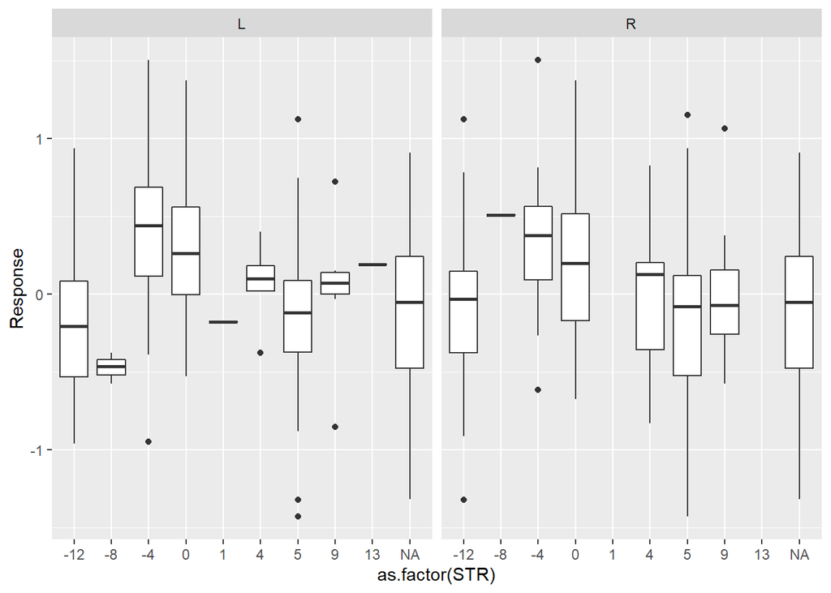

```r
p1 <- ggplot(dat3temp, aes(as.factor(STR),Response)) + facet_grid(~side) + geom_boxplot()


p1
```

The STR(s) chanels are combined “summed” across.

- The chanel has no effect (i.e. left or right), this shows the values are assigned at random.
- The value of the STR should be equal and opposite across the chanel, the values -4 and 4 cancel for example
- The STR and STR^2 are significant along with the interaction of STR and STR^2

```r
### V42 is the start postion we want. start = 42625365

#### Want the STR value to numeric not factor
dat4$STR <- as.numeric(as.character(dat4$V42))
dat4$STRquad <- dat4$STR**2

### Add L/R side can be aribtrary becuase of the model steps above.
### i.e no signifcance when choosing side or STR just need to constent
dat4[seq(1,nrow(dat4),2),"side"] <- "L"
dat4[seq(2,nrow(dat4),2),"side"] <- "R"

dat4[seq(1,nrow(dat4),2),"opside"] <- "R"
dat4[seq(2,nrow(dat4),2),"opside"] <- "L"

### Model with sqaured term.
seplm4a <- lm(dat4$Response ~ dat4$STR + dat4$STRquad + dat4$side )

## STR matter and the squre matters , side L/R does not.
summary(seplm4a)
```

```
##
## Call:
## lm(formula = dat4$Response ~ dat4$STR + dat4$STRquad + dat4$side)
##
## Residuals:
##      Min       1Q   Median       3Q      Max
## -1.43427 -0.33825  0.01143  0.29074  1.37093
##
## Coefficients:
##               Estimate Std. Error t value Pr(>|t|)
## (Intercept)   0.206429   0.041478   4.977 9.64e-07 ***
## dat4$STR     -0.020483   0.005139  -3.986 8.00e-05 ***
## dat4$STRquad -0.004078   0.000601  -6.785 4.22e-11 ***
## dat4$sideR   -0.001241   0.047489  -0.026    0.979
## ---
## Signif. codes:  0 '***' 0.001 '**' 0.01 '*' 0.05 '.' 0.1 ' ' 1
##
## Residual standard error: 0.476 on 398 degrees of freedom
##   (90 observations deleted due to missingness)
## Multiple R-squared:  0.1085, Adjusted R-squared:  0.1018
## F-statistic: 16.15 on 3 and 398 DF,  p-value: 6.316e-10
```

```r
BIC(seplm4a)
```

```
## [1] 570.009
```

```r
seplm4b <- lm(dat4$Response ~ dat4$STR)
summary(seplm4b)
```

```
##
## Call:
## lm(formula = dat4$Response ~ dat4$STR)
##
## Residuals:
##      Min       1Q   Median       3Q      Max
## -1.50798 -0.33355  0.00464  0.31335  1.47467
##
## Coefficients:
##             Estimate Std. Error t value Pr(>|t|)
## (Intercept) 0.048965   0.026166   1.871    0.062 .
## dat4$STR    0.005364   0.003634   1.476    0.141
## ---
## Signif. codes:  0 '***' 0.001 '**' 0.01 '*' 0.05 '.' 0.1 ' ' 1
##
## Residual standard error: 0.5016 on 400 degrees of freedom
##   (90 observations deleted due to missingness)
## Multiple R-squared:  0.005417,   Adjusted R-squared:  0.00293
## F-statistic: 2.179 on 1 and 400 DF,  p-value: 0.1407
```

```r
BIC(seplm4b)
```

```
## [1] 602.0154
```

```r
summary(lm(dat4$Response ~ dat4$STR + abs(dat4$STR)))
```

```
##
## Call:
## lm(formula = dat4$Response ~ dat4$STR + abs(dat4$STR))
##
## Residuals:
##      Min       1Q   Median       3Q      Max
## -1.40242 -0.33603  0.00716  0.29906  1.36712
##
## Coefficients:
##                Estimate Std. Error t value Pr(>|t|)
## (Intercept)    0.264218   0.040033   6.600 1.31e-10 ***
## dat4$STR      -0.013255   0.004386  -3.022  0.00268 **
## abs(dat4$STR) -0.045545   0.006652  -6.847 2.87e-11 ***
## ---
## Signif. codes:  0 '***' 0.001 '**' 0.01 '*' 0.05 '.' 0.1 ' ' 1
##
## Residual standard error: 0.4751 on 399 degrees of freedom
##   (90 observations deleted due to missingness)
## Multiple R-squared:   0.11,  Adjusted R-squared:  0.1055
## F-statistic: 24.65 on 2 and 399 DF,  p-value: 8.041e-11
```

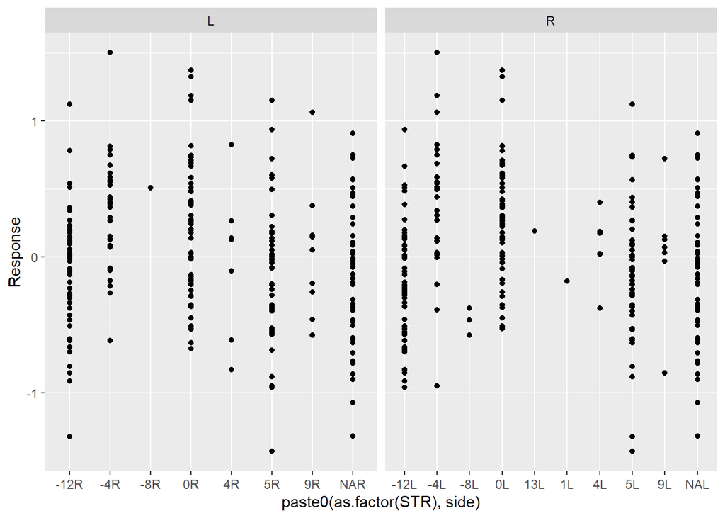

```r
#dat4$V42 <- factor(dat4$V42,levels(dat4$V42)[order(abs(dat4$STR))])
p2a <- ggplot(dat4, aes(paste0(as.factor(STR),side),Response)) + geom_point() + facet_grid(~opside,scales="free_x")

p2a
```

```r
summary(lm(Response~paste0(as.factor(STRquad),side),data = dat4))
```

```
##
## Call:
## lm(formula = Response ~ paste0(as.factor(STRquad), side), data = dat4)
##
## Residuals:
##      Min       1Q   Median       3Q      Max
## -1.29810 -0.32391  0.01027  0.27038  1.28309
##
## Coefficients:
##                                      Estimate Std. Error t value Pr(>|t|)
## (Intercept)                           0.27822    0.06414   4.338 1.76e-05 ***
## paste0(as.factor(STRquad), side)0R   -0.07624    0.09201  -0.829  0.40772
## paste0(as.factor(STRquad), side)144L -0.46205    0.09071  -5.094 5.07e-07 ***
## paste0(as.factor(STRquad), side)144R -0.40253    0.09156  -4.396 1.36e-05 ***
## paste0(as.factor(STRquad), side)169L -0.08780    0.47998  -0.183  0.85494
## paste0(as.factor(STRquad), side)16L   0.04910    0.10683   0.460  0.64601
## paste0(as.factor(STRquad), side)16R  -0.02035    0.10114  -0.201  0.84061
## paste0(as.factor(STRquad), side)1L   -0.45599    0.47998  -0.950  0.34259
## paste0(as.factor(STRquad), side)25L  -0.41517    0.09396  -4.419 1.23e-05 ***
## paste0(as.factor(STRquad), side)25R  -0.41232    0.09396  -4.388 1.41e-05 ***
## paste0(as.factor(STRquad), side)64L  -0.75203    0.28202  -2.667  0.00792 **
## paste0(as.factor(STRquad), side)64R   0.23091    0.47998   0.481  0.63068
## paste0(as.factor(STRquad), side)81L  -0.24819    0.19089  -1.300  0.19417
## paste0(as.factor(STRquad), side)81R  -0.27440    0.16353  -1.678  0.09400 .
## paste0(as.factor(STRquad), side)NAL  -0.39488    0.09561  -4.130 4.29e-05 ***
## paste0(as.factor(STRquad), side)NAR  -0.39488    0.09561  -4.130 4.29e-05 ***
## ---
## Signif. codes:  0 '***' 0.001 '**' 0.01 '*' 0.05 '.' 0.1 ' ' 1
##
## Residual standard error: 0.4757 on 476 degrees of freedom
## Multiple R-squared:  0.1485, Adjusted R-squared:  0.1217
## F-statistic: 5.536 on 15 and 476 DF,  p-value: 1.936e-10
```

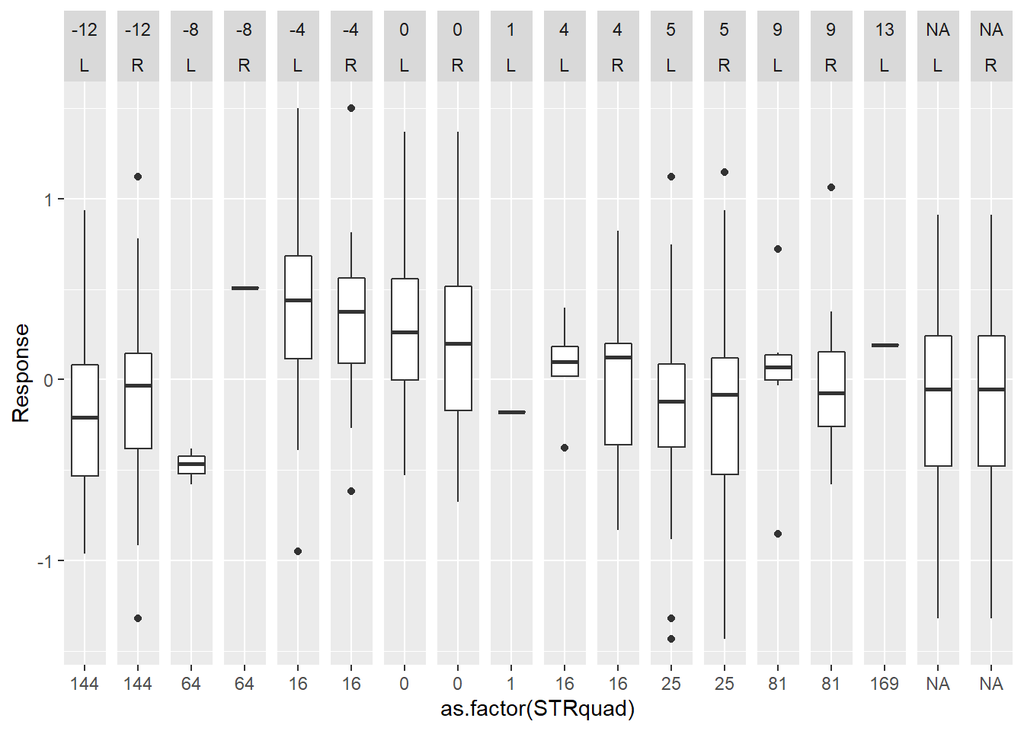

```r
p2 <- ggplot(dat4, aes(as.factor(STRquad),Response)) + geom_boxplot() + facet_grid(~STR+side,scales="free_x")

p2
```

```r
dat5 <- aggregate(dat4[,c("STR","STRquad")],by=list(dat4$Gene,dat4$Response),FUN=sum,na.rm=TRUE)

names(dat5) <- c("Gene","y","STR","STRsqr")



agglm <- lm(y ~ STR+STR*STRsqr,dat=dat5)
summary(agglm)
```

```
##
## Call:
## lm(formula = y ~ STR + STR * STRsqr, data = dat5)
##
## Residuals:
##      Min       1Q   Median       3Q      Max
## -1.46469 -0.32916  0.03344  0.30942  1.22551
##
## Coefficients:
##               Estimate Std. Error t value Pr(>|t|)
## (Intercept)  1.458e-01  4.533e-02   3.216 0.001475 **
## STR         -2.701e-02  7.974e-03  -3.387 0.000826 ***
## STRsqr      -1.724e-03  5.999e-04  -2.874 0.004416 **
## STR:STRsqr   8.863e-05  4.182e-05   2.119 0.035090 *
## ---
## Signif. codes:  0 '***' 0.001 '**' 0.01 '*' 0.05 '.' 0.1 ' ' 1
##
## Residual standard error: 0.4861 on 242 degrees of freedom
## Multiple R-squared:  0.09588,    Adjusted R-squared:  0.08467
## F-statistic: 8.555 on 3 and 242 DF,  p-value: 2.02e-05
```

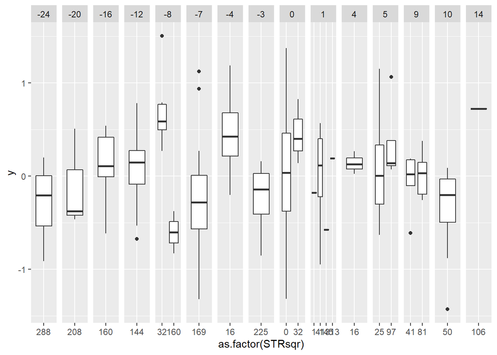

```r
p3 <- ggplot(dat5, aes(as.factor(STRsqr),y)) + geom_boxplot() + facet_grid(~STR,scales="free_x")

p3
```

```r
#agglmcat <- lm(dat5$Group.2~ as.factor(dat5$STR)+as.factor(dat5$STRquad))
#summary(agglmcat)

summary(lm(dat5$y ~ dat5$STR))
```

```
##
## Call:
## lm(formula = dat5$y ~ dat5$STR)
##
## Residuals:
##      Min       1Q   Median       3Q      Max
## -1.49266 -0.33472  0.00508  0.31455  1.51003
##
## Coefficients:
##             Estimate Std. Error t value Pr(>|t|)
## (Intercept) 0.022510   0.034610   0.650    0.516
## dat5$STR    0.003795   0.003538   1.073    0.284
##
## Residual standard error: 0.5079 on 244 degrees of freedom
## Multiple R-squared:  0.004693,   Adjusted R-squared:  0.0006143
## F-statistic: 1.151 on 1 and 244 DF,  p-value: 0.2845
```

```r
dat5$linsum <- dat5$STR + dat5$STRsqr
dat5$linsumint <- dat5$STR + dat5$STRsqr + (dat5$STR*dat5$STRsqr)

linmodsqr <- lm(dat5$y ~ dat5$linsum)

BIC(linmodsqr)
```

```
## [1] 366.159
```

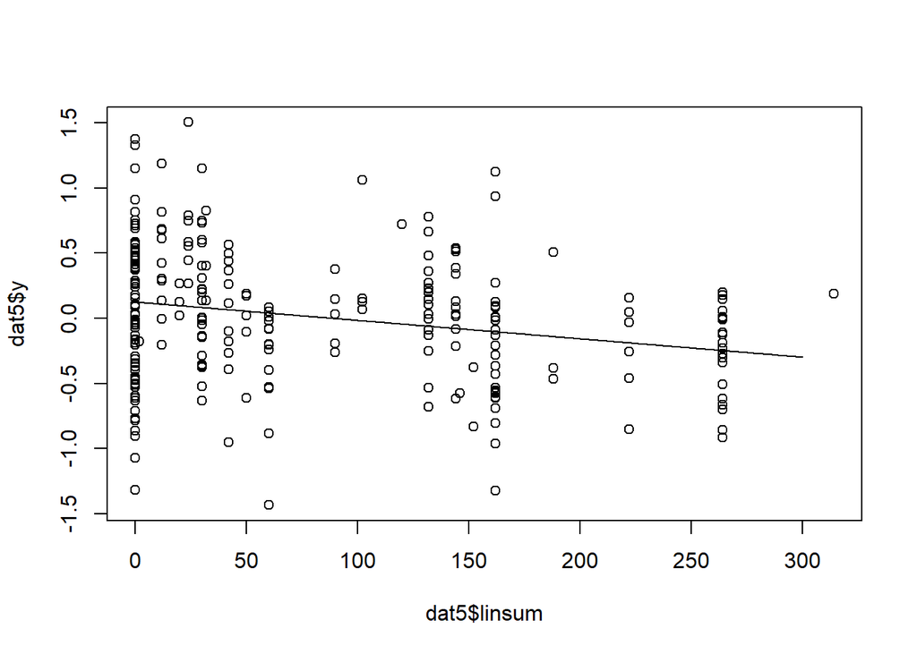

```r
#(Intercept)  0.1240251  0.0434871   2.852 0.004717 **
#dat5$linsum -0.0014102  0.0003685  -3.827 0.000165 ***

xvals <- seq(0,300,1)

plot(dat5$linsum,dat5$y)
lines(xvals,0.124-0.00141*xvals)
```

```r
linmodsqrint <- lm(dat5$y ~ dat5$linsumint)

BIC(linmodsqrint)
```

```
## [1] 373.9619
```

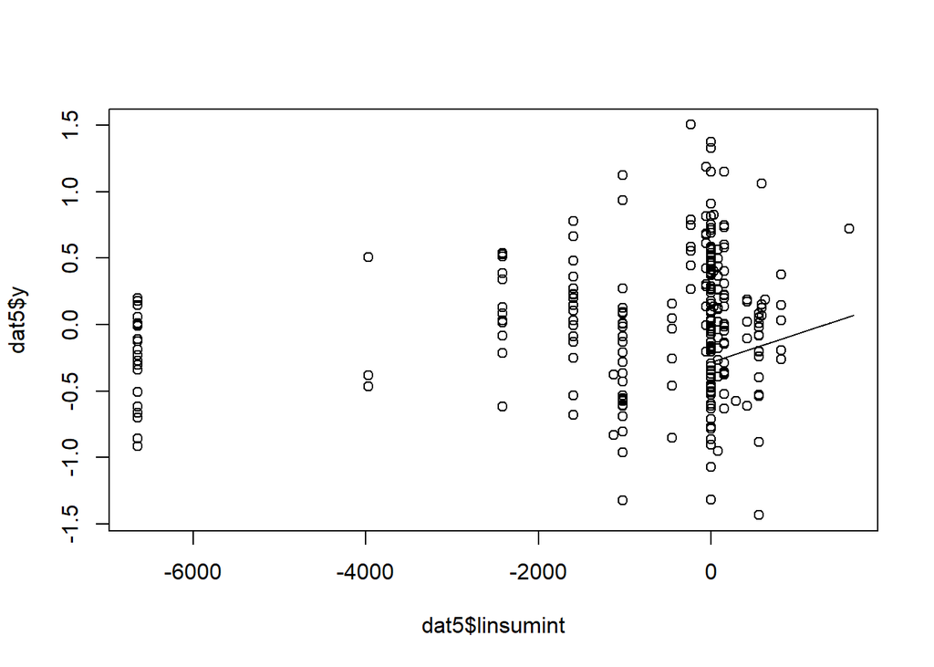

```r
xvals <- seq(-6650,1600,5)

plot(dat5$linsumint,dat5$y)
lines(x=0.0000427*xvals)
```

```r
#mf <- model.frame(agglm)
#plot(mf[,"dat5$Group.2"],predict(agglm))
#xvals <- seq(-24,14,length.out=246)
#fitvals <- 0.158 -0.0144*xvals - 0.00234*xvals**2
#plot(mf[,"dat5$Group.2"],predict(agglm),col=as.factor(mf[,"dat5$STR"]))
#lines(mf[,"dat5$Group.2"],fitvals)
```